# Lab 6 Answer Sheet

BIOS 10602 - Multiscale Modeling of Biological Systems

9/22/2021

## Part 1: Local Sequence Alignment Continued

1.1

```r
alignmentMatrix <- function(seq1, seq2, scoreMat){
  amatrix<- matrix(0, ncol=length(x)+1, nrow=length(y)+1)
  rownames(amatrix) <- c("", y)
  colnames(amatrix) <- c("", x)

  gap <- scoreMat["-", ][[1]]

  for(i in 2:nrow(amatrix)) {
    for(j in 2:ncol(amatrix)) {
        l = amatrix[i-1, j] + gap
        t = amatrix[i, j-1] + gap
        lt = amatrix[i-1, j-1] + scoreMat[rownames(amatrix)[i], colnames(amatrix)[j]]
        amatrix[i, j] <- max(l, t, lt, 0)
    }
  }
  return(amatrix)
}
```

1.2

```r
y <- strsplit("GATCCATTAAGCGCAAATGGCCA", "")[[1]]
x <- strsplit("GATTTCAGGCAGTACA", "")[[1]]

lut <- matrix(-1, 5, 5)
diag(lut) <- 3
dimnames(lut) <- list(c("A", "C", "G", "T", "-"), c("A", "C", "G", "T", "-"))
lut[, "-"] <- -2
lut["-", ] <- -2

alignmentMatrix(x, y, lut)
```

```
##     G A T T T C  A  G  G  C  A  G  T  A  C  A
##   0 0 0 0 0 0 0  0  0  0  0  0  0  0  0  0  0
## G 0 3 1 0 0 0 0  0  3  3  1  0  3  1  0  0  0
## A 0 1 6 4 2 0 0  3  1  2  2  4  2  2  4  2  3
## T 0 0 4 9 7 5 3  1  2  0  1  2  3  5  3  3  1
## C 0 0 2 7 8 6 8  6  4  2  3  1  1  3  4  6  4
## C 0 0 0 5 6 7 9  7  5  3  5  3  1  1  2  7  5
## A 0 0 3 3 4 5 7 12 10  8  6  8  6  4  4  5 10
## T 0 0 1 6 6 7 5 10 11  9  7  6  7  9  7  5  8
## T 0 0 0 4 9 9 7  8  9 10  8  6  5 10  8  6  6
## A 0 0 3 2 7 8 8 10  8  8  9 11  9  8 13 11  9
## A 0 0 3 2 5 6 7 11  9  7  7 12 10  8 11 12 14
## G 0 3 1 2 3 4 5  9 14 12 10 10 15 13 11 10 12
## C 0 1 2 0 1 2 7  7 12 13 15 13 13 14 12 14 12
## G 0 3 1 1 0 0 5  6 10 15 13 14 16 14 13 12 13
## C 0 1 2 0 0 0 3  4  8 13 18 16 14 15 13 16 14
## A 0 0 4 2 0 0 1  6  6 11 16 21 19 17 18 16 19
## A 0 0 3 3 1 0 0  4  5  9 14 19 20 18 20 18 19
## A 0 0 3 2 2 0 0  3  3  7 12 17 18 19 21 19 21
## T 0 0 1 6 5 5 3  1  2  5 10 15 16 21 19 20 19
## G 0 3 1 4 5 4 4  2  4  5  8 13 18 19 20 18 19
## G 0 3 2 2 3 4 3  3  5  7  6 11 16 17 18 19 17
## C 0 1 2 1 1 2 7  5  3  5 10  9 14 15 16 21 19
## C 0 0 0 1 0 0 5  6  4  3  8  9 12 13 14 19 20
## A 0 0 3 1 0 0 3  8  6  4  6 11 10 11 16 17 22
```

1.3

```r
source("pairAlign.R")
pairAlign("GATCCATTAAGCGCAAATGGCCA", "GATTTCAGGCAGTACA", substitutionMatrix = "lut", gapExtension = -2, type = "local")
```

```
## $Pattern
## [1] "GATCCATTAAGCGCAAATGGCCA"
##
## $Subject
## [1] "GAT---TTCAG-GC--A-GTACA"
##
## $Score
## [1] 22
```

22

```r
#modified version of generateSeqsWithMultinomialModel() from https://a-little-book-of-r-for-bioinformatics.readthedocs.io/en/latest/src/chapter4.html

generateSeqs <- function(inputsequence, X){
  #split inputted string into vector of individual characters
  inputsequencevector <- strsplit(inputsequence,"")[[1]]
  mylength <- length(inputsequencevector)
  mytable <- table(inputsequencevector)
  letters <- rownames(mytable)
  probabilities <- mytable/mylength #store the probabilities of letters

  #sample total number of characters needed to generate X random sequences of length myLength
  seqset <- sample(letters, mylength*X, rep=TRUE, prob=probabilities)

  #apply paste0() to collapse vector of characters into a vector of character strings of the original length
  seqs <- vapply(seq(1, mylength*X, mylength), function(i) paste0(seqset[i:(i+(mylength-1))], collapse = ''), inputsequence)

  return(seqs)
}
```

1.4

```r
y <- strsplit("MVWHDVDEGFHTAVW", "")[[1]]
x <- strsplit("AHDVGVWGHDD", "")[[1]]
pairAlign("MVWHDVDEGFHTAVW", "AHDVGVWGHDD", substitutionMatrix = "BLOSUM62", gapOpening = -12, gapExtension = -3, type = "global")
```

```
## $Pattern
## [1] "MVWHDVDEGFHTAVW"
##
## $Subject
## [1] "A--HDVGVWGHDD--"
##
## $Score
## [1] -22
```

-22

1.5

```r
scores <- numeric(2000)
seqs <- generateSeqs("MVWHDVDEGFHT", 2000)

for (i in 1:length(seqs)) {
  scores[i] <- pairAlign(seqs[i], "AHDVGVWGHDD", substitutionMatrix = "BLOSUM62", gapOpening = -10, gapExtension = -2, scoreOnly = TRUE, type="global")
}
```

1.6

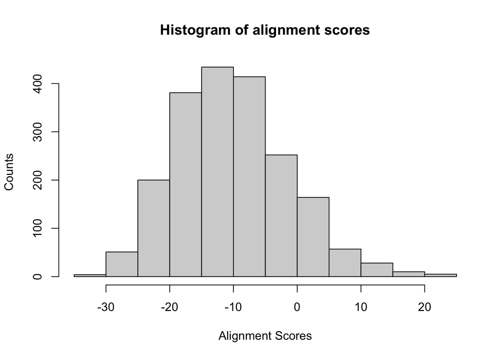

```r
hist(scores, xlab="Alignment Scores", ylab="Counts", main="Histogram of alignment scores")
```

```r
count <- 0
for (score in scores) {
  if (score >= -22) {
    count <- count + 1
  }
}

count/length(seqs)
```

```
## [1] 0.9445
```

## Part 2: Multiple sequence alignment

```r
# INPUT ARGUMENTS
# patterns : list of char vectors
#            each vector patterns[[i]] contains the version of the CENTER sequence that arises from the pairwise alignment between the center sequence and sequence[i]
# subjects : list of char vectors
#            each vector subjects[[i]] contains the alignment of sequence[i] after a pairwise alignment with the center sequence
# center   : integer
#            index of the sequence in the original sequence list that is the center.
buildMSA <- function(patterns, subjects, center) {
    MSA <- rbind(patterns[[1]], subjects[[1]])
    for(i in 2:length(patterns)) {
        j = 1 #index in new row
        k = 1 #index in alignment of center sequence to sequence i
        m = 1 #column index of MSA
        maxLength = ncol(MSA) + length(patterns[[i]])
        newRow = character(maxLength)
        while(k <= length(patterns[[i]]) && m <= ncol(MSA)) {
            if(patterns[[i]][k] == MSA[1, m]) {
                newRow[j] <- subjects[[i]][k]
                j <- j + 1
                k <- k + 1
                m <- m + 1
            } else if(MSA[1, m] == "-") {
                newRow[j] <- "-"
                j <- j + 1
                m <- m + 1
            } else if(patterns[[i]][k] == "-") {
                if(m == 1) {
                    MSA <- cbind(rep("-", nrow(MSA)), MSA)
                } else {
                    MSA <- cbind(MSA[, 1:(m-1)], rep("-", nrow(MSA)), MSA[, m:ncol(MSA)])
                }
                newRow[j] <- subjects[[i]][k]
                m <- m + 1
                j <- j + 1
                k <- k + 1
            }
        }
        while(k <= length(patterns[[i]])) {
            MSA <- cbind(MSA, rep("-", nrow(MSA)))
            newRow[j] <- subjects[[i]][k]
            k <- k + 1
            j <- j + 1
        }
        while(m <= ncol(MSA)) {
            newRow[j] <- "-"
            m <- m + 1
            j <- j + 1
        }
        newRow <- newRow[1:(m - 1)]
        MSA <- rbind(MSA, newRow)
    }
    rownames(MSA) <- c("    Center:", paste0("Sequence ", 1:(nrow(MSA)), ":")[-center])
    colnames(MSA) <- 1:ncol(MSA)
    return(MSA)
}
```

2.1 a  
The first pair of pattern and subject is added to the multiple alignment matrix. Then, each subsequent pattern is compared to that first pattern. If the first has a gap the new pattern does not, a gap is added to the new subject accordingly and it is inserted into the matrix. If the new pattern has a gap the first pattern does not, the gap is added accordingly to all present sequences in the matrix to align with the new pattern, whose subject is then added as is.

2.1 b  
The gap is added to all above sequences at the same position as in the new center sequence. The function does this by splitting the matrix at that column, and then recombining those two splits around a column of gaps. The sequence i is then added

2.2 For each sequence, we don’t need to compare it against itself. We also don’t need to compare it with previous sequences, as those sequences have already been compared with this one in past iterations. Therefore, we must only align it with sequences it hasn’t interacted with, or, those to the right of it in the vector. The for loop accomplishes this by, in the inner for loop, setting the start point to be the sequence after the sequence of interest.

```r
sequences <- c("PVWHTAE", "HEVGAWGHEE", "PMCWGHVE") #these are the sequences that you should be working with.
```

2.3

```r
## Initialization
n <- length(sequences)
align1 <- matrix("", n, n)
align2 <- align1

## Generate alignments
for(i in 1:(n-1)) {
    for(j in (i+1):n) {
        alignment <- pairAlign(sequences[i], sequences[j], "BLOSUM62", gapOpening=-6, gapExtension=-3)
        align1[j, i] <- alignment[[1]]
        align2[i, j] <- alignment[[1]]
        align2[j, i] <- alignment[[2]]
        align1[i, j] <- alignment[[2]]
    }
}

align1
```

```
##      [,1]         [,2]         [,3]
## [1,] ""           "HEVGAWGHEE" "PMCWGHVE"
## [2,] "---PVWHTAE" ""           "PM--CWGHVE"
## [3,] "PV-WHTAE"   "HEVGAWGHEE" ""
```

```r
align2
```

```
##      [,1]         [,2]         [,3]
## [1,] ""           "---PVWHTAE" "PV-WHTAE"
## [2,] "HEVGAWGHEE" ""           "HEVGAWGHEE"
## [3,] "PMCWGHVE"   "PM--CWGHVE" ""
```

2.4

```r
distances <- sapply(mapply(`!=`, strsplit(align1, ""), strsplit(align2, "")), sum)
distanceMatrix <- matrix(distances, n, n)
dimnames(distanceMatrix) = list(sequences, sequences)
distanceMatrix
```

```
##            PVWHTAE HEVGAWGHEE PMCWGHVE
## PVWHTAE          0          8        5
## HEVGAWGHEE       8          0        6
## PMCWGHVE         5          6        0
```

2.5  
Each column, or row for that matter, corresponds to the distance between that sequence and all other sequences when aligned. Taking the sum of the column or row gives a number describing how well or poor the sequence aligns with all other sequences. Therefore, the sequence with the smallest total distance best aligns with all others and should be used as the center.

2.6

```r
names(which.min(colSums(distanceMatrix)))[1]
```

```
## [1] "PMCWGHVE"
```